# Data Warehouse & Business Intelligence

Data Lab & Implementation

Cevi Herdian, M. Sc, SFC (itsmecevi.github.io)

25.09.2019

**Note:**

-An R Notebook is an R Markdown document with chunks that can be executed independently and interactively, with output visible immediately beneath the input.

-Notebook output are available as HTML, PDF, Word, or Latex.

-This Notebook as HTML is preferably open with Google Chrome.

-R-Code can be extracted as Rmd file under the button “Code” in the notebook.

-This Notebook using iterative development. It means the process starts with a simple implementation of a small set of idea requirements and iteratively enhances the evolving versions until the complete version is implemented and perfect.

**Glossary:**

- BI-> Business Intelligence
- DBMS-> Database Management System
- RDBMS-> Relational Database Management System
- SQL-> Structured Query Language
- OLTP-> Online Transactional Processing. OLTP typically involves inserting, updating, and/or deleting small amounts of data in a database.
- OLAP-> Online analytical processing.

# Overview

**1. References:**

- Feel free
- This modul (only for test)

**2. Methods:** ENJOY THE MOMENT

**3. Tools:**

- Trello Apps-> please Sign up the Trello (trello.com or App Store: Trello)
- Who is the admin? as a gift: 5% additional point

**4. Contents:**

- Lectures
- Data lab (implementation of software)
- MEQA (Mock Exams Questions and Answers)
- Test-> one BI project 50% + (Multiple Choice AND/OR Explanation Test AND/OR Use Case) 50%
- One optional BI project (10%)

**4. Software:** (On Premises & Cloud)

> Note! The biggest difference between these two systems is how they are deployed. Cloud-based software is hosted on the vendor’s servers and accessed through a web browser. On-premise software is installed locally, on a company’s own computers and servers.
- Excel Business Inteligence
- Power BI
- Tableau
- Pentaho
- Sisense
- Alteryx
- Looker
- Oracle BI
- MySQL BI
- Microsoft SQL Server
- SAP BI
- MicroStrategy
- TIBCO Spotfire
- Domo BI
- QlickView
- SAS BI
- Klipfolio
- Geckoboard
- Hadoop
- Jaspersoft
- Zoho Analytics
- PostgreSQL
- IBM Db2
- Mongo DB . . .etc
5. We need data! datamart
- https://opendata.socrata.com/
- https://www.data.gov/
- https://data.worldbank.org/
- https://academictorrents.com/
- https://data.world/
- https://www.quandl.com/
- https://archive.ics.uci.edu/ml/index.php
- https://www.kaggle.com/
- https://data.go.id/dataset?q=subang
- http://data.jakarta.go.id/
- http://data.bandung.go.id/
- https://opendata.subang.go.id/
- http://satudata.jabarprov.go.id/#
6. Extras:
- How to choose the one that fit our needs!
- Anybody wants to get certificate? (optional)

# Database

**What is a Data?**

- Data is a collection of facts, such as numbers, words, measurements, observations or even just descriptions of things.
- In general, data is any set of characters that is gathered and translated for some purpose, usually analysis. It can be any character, including text and numbers, pictures, sound, or video. If data is not put into context, it doesn’t do anything to a human or computer.
- Data can be qualitative or quantitative. Put simply: Discrete data is counted, Continuous data is measured.
  - Qualitative data is descriptive information (it describes something)
  - Quantitative data is numerical information (numbers)-> Discrete(5,6,10); Continuous (3,14)
- Example: What do we know about Indonesia’s flag, length=width 10 cm, white and red color?

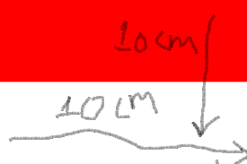

```r
#Qualitative: The flag has white and red color
#Quantitative: The flag has length 10 cm and width 10 cm
```

**What is a Database?**

- A database is a collection of related data which represents some aspect of the real world. A database system is designed to be built and populated with data for a certain task.
- A database is an electronic administration system that has to handle large amounts of data efficiently, without contradiction, permanently and can represent logical relationships digitally.
- A database is an organized collection of structured information, or data, typically stored electronically in a computer system. A database is usually controlled by a **database management system (DBMS)**. Together, the data and the DBMS, along with the applications that are associated with them, are referred to as a database system, often shortened to just database.
- Data within the most common types of databases in operation today is typically modeled in rows and columns in a series of tables to make processing and data querying efficient. The data can then be easily accessed, managed, modified, updated, controlled, and organized. Most databases use **structured query language (SQL)** for writing and querying data.
- A database typically requires a comprehensive database software program known as a database management system (DBMS). A DBMS serves as an interface between the database and its end users or programs, allowing users to retrieve, update, and manage how the information is organized and optimized. A DBMS also facilitates oversight and control of databases, enabling a variety of administrative operations such as performance monitoring, tuning, and backup and recovery. Some examples of popular database software or DBMSs include MySQL, Microsoft Access, Microsoft SQL Server, FileMaker Pro, Oracle Database, and dBASE.

**What Is Structured Query Language (SQL)?**

- SQL is a programming language used by nearly all relational databases to query, manipulate, and define data, and to provide access control. SQL was first developed at IBM in the 1970s with Oracle as a major contributor, which led to implementation of the SQL ANSI standard, SQL has spurred many extensions from companies such as IBM, Oracle, and Microsoft. Although SQL is still widely used today, new programming languages are beginning to appear (**example: NoSQL**).

**What’s the Difference Between a Database and a Spreadsheet?**

Databases and spreadsheets (such as Microsoft Excel) are both convenient ways to store information. The primary differences between the two are:

- How the data is stored and manipulated
- Who can access the data
- How much data can be stored

Spreadsheets were originally designed for one user, and their characteristics reflect that. They’re great for a single user or small number of users who don’t need to do a lot of incredibly complicated data manipulation. Databases, on the other hand, are designed to hold much larger collections of organized information-massive amounts, sometimes. Databases allow multiple users at the same time to quickly and securely access and query the data using highly complex logic and language.

**What is DBMS?**

- Database Management System (also known as DBMS) is a software for storing and retrieving users’ data by considering appropriate security measures. It allows users to create their own databases as per their requirement.
- It consists of a group of programs which manipulate the database and provide an interface between the database. It includes the user of the database and other application programs.
- The DBMS accepts the request for data from an application and instructs the operating system to provide the specific data. In large systems, a DBMS helps users and other third-party software to store and retrieve data.

**Example of a DBMS (exactly: RDBMS, see on the types of databases)**

- The STUDENT file stores data of each student
- The COURSE file stores contain data on each course.
- The GRADE file stores the grades which students receive in the various sections
- The TUTOR file contains information about each tutor.

->To define a database system:

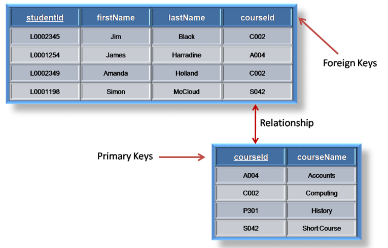

->Example: Create the Unsub database with the following data (see the above pict. as example)

STUDENT: A, B, C, D, E

COURSE: Math, Bio, Art, BI, Data

GRADE: 100, 90, 80, 50, 95

TUTOR: F, G, H, I, J

```r
#See on the WHITEBOARD!
```

**History of DBMS**

Here, are the important landmarks from the history:

- 1960 - Charles Bachman designed first DBMS system
- 1970 - Codd introduced IBM’S Information Management System (IMS)
- 1976- Peter Chen coined and defined the Entity-relationship model also know as the ER model
- 1980 - Relational Model becomes a widely accepted database component
- 1985- Object-oriented DBMS develops.
- 1990s- Incorporation of object-orientation in relational DBMS.
- 1991- Microsoft ships MS access, a personal DBMS and that displaces all other personal DBMS products.
- 1995: First Internet database applications
- 1997: XML applied to database processing. Many vendors begin to integrate XML into DBMS products.
- 2000s: New interactive applications were developed for PDAs, point-of-sale transactions, and consolidation of vendors. Presently, the three leading database companies in the western world are Microsoft, IBM, and Oracle.
- Today, databases are everywhere and are used to enhance our day-to-day life. From personal cloud storage to predicting the weather, many of the services we utilize today are possible due to databases. Presently, there are many new players in the **non-relational database** space offering specific solutions. Some of the current relational databases include giants such as Oracle, MySQL, and DB2.

The boom in unstructured data that the world has seen in the last few years is one of the main reasons relational databases are no longer sufficient for many companies’ needs. It comes up **non-relational database** (not in this lecture!).

**Characteristics of Database Management System**

- Provides security and removes redundancy
- Self-describing nature of a database system
- Insulation between programs and data abstraction
- Support of multiple views of the data
- Sharing of data and multiuser transaction processing
- DBMS allows entities and relations among them to form tables.
- It follows the ACID concept ( Atomicity, Consistency, Isolation, and Durability).
- DBMS supports multi-user environment that allows users to access and manipulate data in parallel.

**DBMS vs. Flat File**

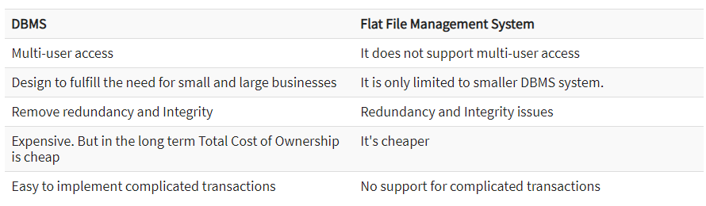

**Popular DBMS Software**

Here, is the list of some popular DBMS system:

- MySQL
- Microsoft Access
- Oracle
- PostgreSQL
- dBASE
- FoxPro
- SQLite
- IBM DB2
- LibreOffice Base
- MariaDB
- Microsoft SQL Server etc.

**Application of DBMS**

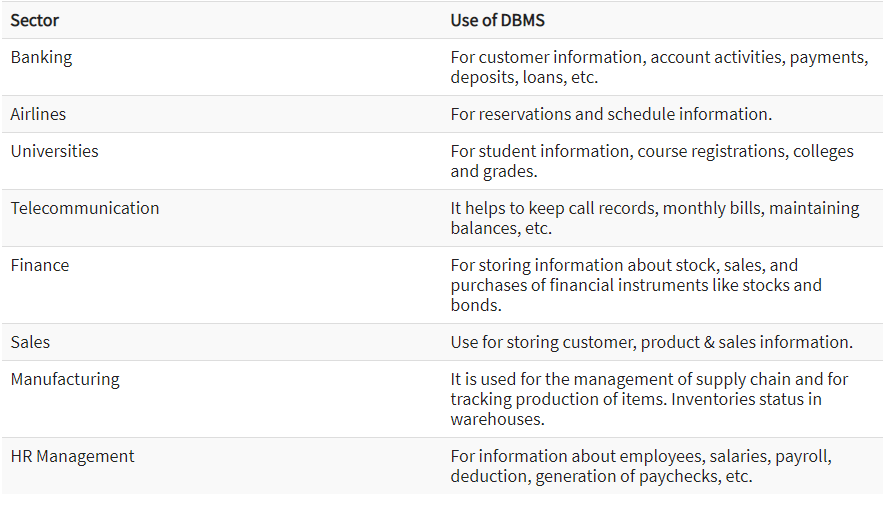

**Types of Databases**

There are many different types of databases. The best database for a specific organization depends on how the organization intends to use the data.

- **Relational databases**. Relational databases became dominant in the 1980s. Items in a relational database are organized as a set of tables with columns and rows. Relational database technology provides the most efficient and flexible way to access structured information.

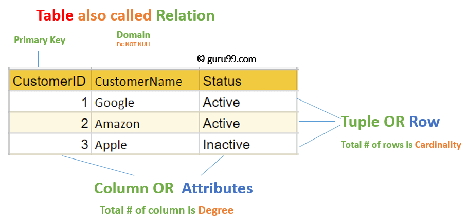

- **Object-oriented databases**. Information in an object-oriented database is represented in the form of objects, as in object-oriented programming. Object oriented data model is one of the developed data model and this can hold the audio, video and graphic files.

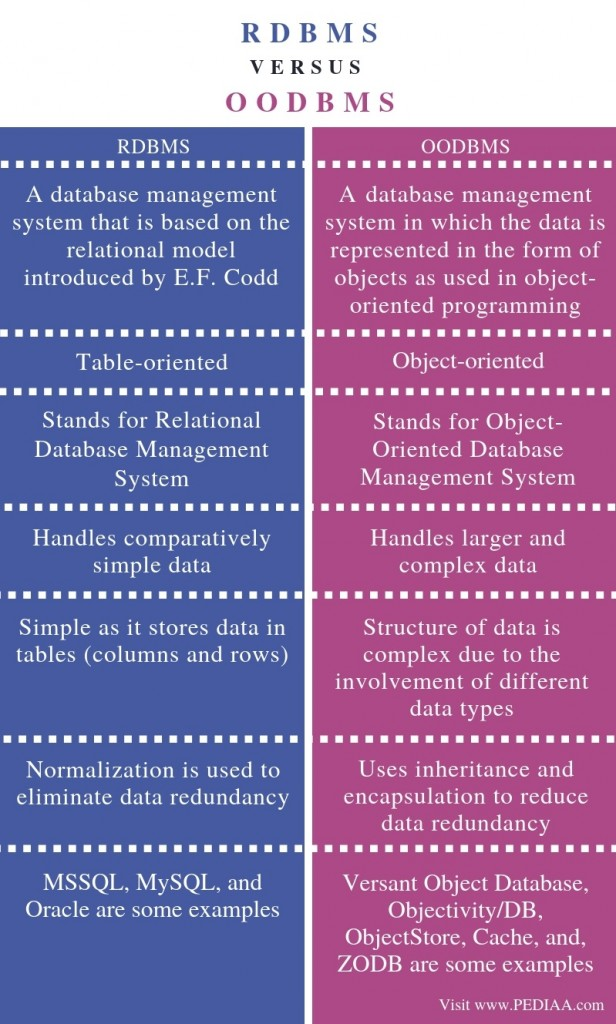

- **Distributed databases**. A distributed database consists of two or more files located in different sites. The database may be stored on multiple computers, located in the same physical location, or scattered over different networks. **See also distributed computing or distributed system on big data!**

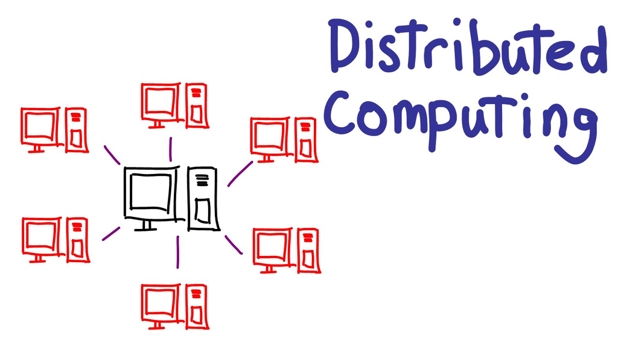

- **Data warehouses**. A central repository for data, a data warehouse is a type of database specifically designed for fast query and analysis.

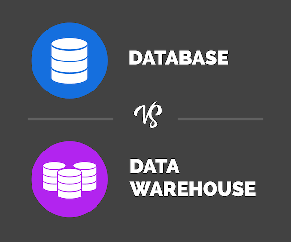

- **NoSQL databases**. A NoSQL, or nonrelational database, allows unstructured and semistructured data to be stored and manipulated (in contrast to a relational database, which defines how all data inserted into the database must be composed). NoSQL databases grew popular as web applications became more common and more complex.

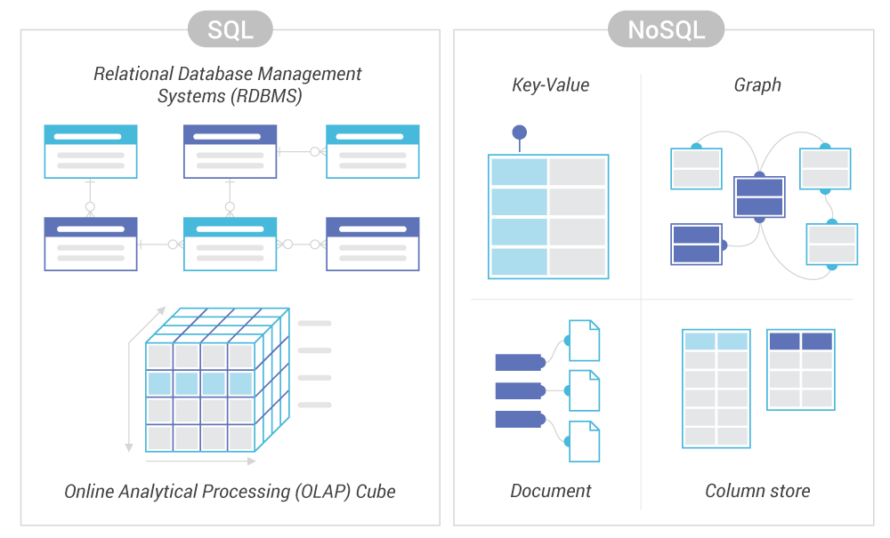

- **Graph databases**. A graph database stores data in terms of entities and the relationships between entities.

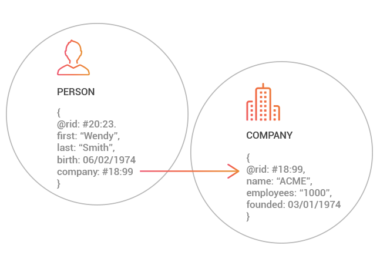

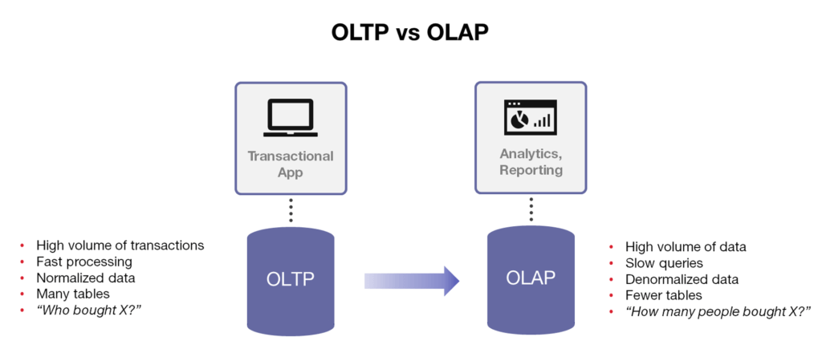

# Data Warehouse

# Business Intelligence

# Big Data

# Data Lake

# Data Lab

# Change log update

- 25.09.2019

# Preferences

- [Authoring Books and Technical Documents with R Markdown](https://bookdown.org/yihui/bookdown/)
- [R Markdown: The Definitive Guide](https://bookdown.org/yihui/rmarkdown/)
- [Datenbanken Verstehen](http://www.datenbanken-verstehen.de/)
- [Tutorialspoint](https://www.tutorialspoint.com/index.htm)
- [Software Advice](https://www.softwareadvice.com/)
- Oracle
- Math is Fun
- [Java T Point](https://www.javatpoint.com/)
- Medium
- [Alooma Data Pipeline](https://www.alooma.com/)
- [SQl Database Modeler](https://sqldbm.com/Home/)
- [Datenbanksysteme: Eine Einführung](https://www.amazon.de/Datenbanksysteme-Eine-Einf%C3%BChrung-Gruyter-Studium/dp/3110443759/ref=sr_1_2?__mk_de_DE=%C3%85M%C3%85%C5%BD%C3%95%C3%91&keywords=datenbanken&qid=1569426544&s=books&sr=1-2)
- [Datenbanken und SQL](https://www.amazon.de/Datenbanken-SQL-praxisorientierte-Einf%C3%BChrung-Anwendungen/dp/3658161280/ref=sr_1_5?__mk_de_DE=%C3%85M%C3%85%C5%BD%C3%95%C3%91&keywords=datenbanken&qid=1569426544&s=books&sr=1-5)
- Datenmanagement:Daten-Datenbanken-Datensicherheit

# License

MIT